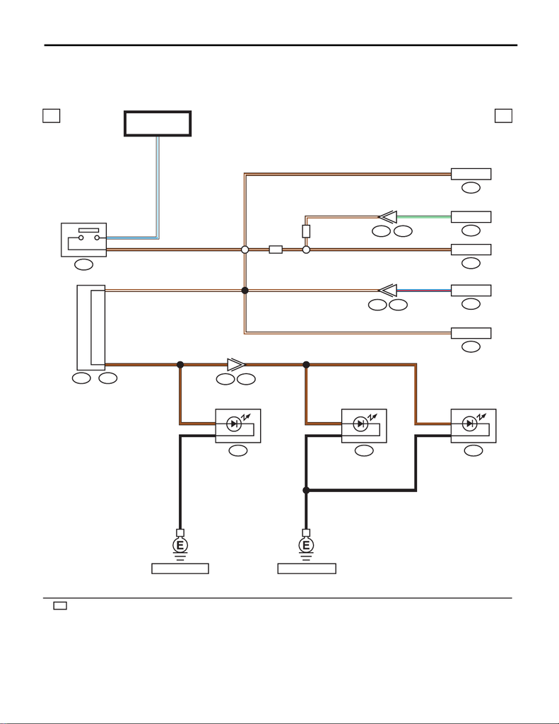

WI-397

Stop Light System

WIRING SYSTEM

53.Stop Light System

A: WIRING DIAGRAM

1. ENGINE TYPE FA

WI-44587

18

4

7

WP

B576B575

B65

R168B:B159F:

E158B:

B280A:

B572A:

B54

B310

R28 R26 R19

R81 R82

B22 E3

WP

F/B

W/L

BR/W2

W/L1

BR/WF9

BRB15

L/R B8

BR/W A10

LG A18

BR/W 29

BR/W

27

BR/W

6BR

B2

B

B

6BR

B2

BR

B

1

2

BR

BR

BR/W

VDC CM

TCM

ECM

CVT

HIGH-MOUNTED

STOP LIGHT

REAR

COMBINATION

LIGHT RH

REAR

COMBINATION

LIGHT LH

KEYLESS

ACCESS CM

BODY

INTEGRATED UNIT

FB-3

F/B FUSE NO. 8

(B)

STOP LIGHT &

BRAKE SWITCH

: WITH PUSH BUTTON START

REF. TO GND [h]REF. TO GND [f]

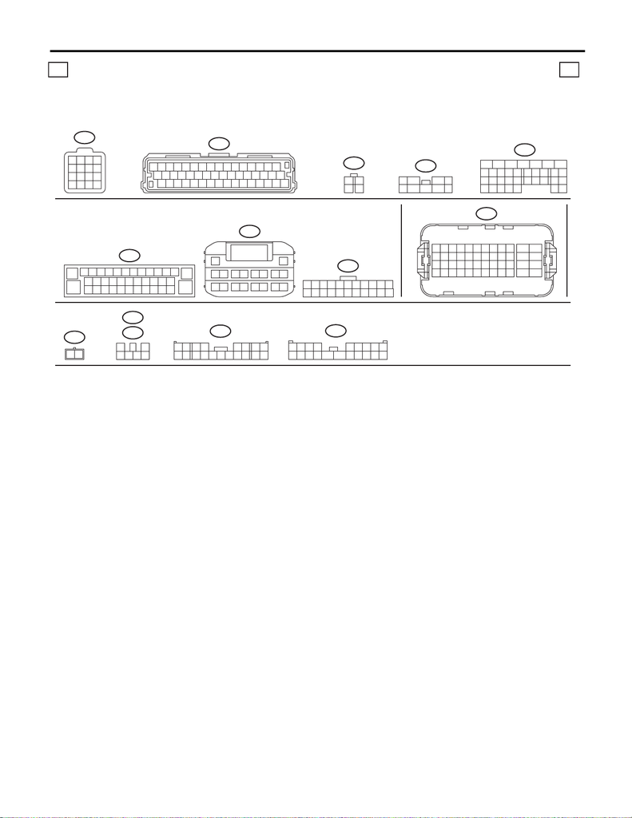

WI-398

Stop Light System

WIRING SYSTEM

WI-44588

1b 1b

456789

10 11

B575

11 12

34

13 14

56

15 16

78

17 18

10

9

12

B572A:

(BR)

B22

12

3

4

5678

9

10 11 12

1413 15 16

(B)

B65

12

34

B159F:

1

5

76

2

8

34

9

B280

18

2719 20 21 22

23

26

24

25

98

15

1413121110

17

16

1234567

A:

B310

23456789

1

10 11 12 13

14

15

26

16 17 18 19 20 21 22 23 24 25

27 28 29 30 31 32 33 34 35 36 37

38

E158

(B)

79

10

85

23

11 12

6

19 21 222017

24

35 36

47 48

18

31 33 343229 30

43 45 464441 42

3412

15 1613 14

27 2825 26

39 4037 38

B:

5

6

34

21

R28

R26

R168B:

1234

56789

10 11 12 13 14 15 16 17 18 19 20

(B)

R82

1

9

234 5678

10 11 12 14 15 16 17 18 1913

R19

12

(B)

B54

123456789

10 11 12 13 14 15 16

17 18 19 20 21 22 23 24 25 26 27 28 29 30 31 32

33 34 35 36 37 38 39 40 41 42 43 44 45 46 47 48

LIST OF CONNECTORS

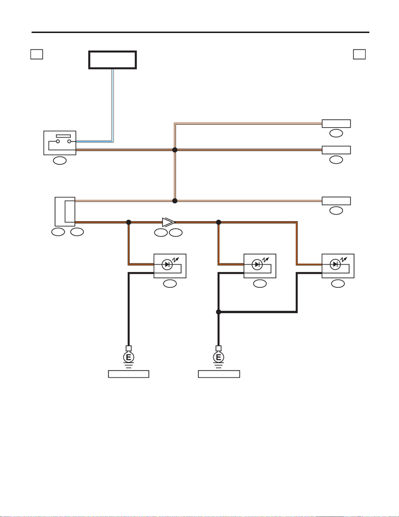

WI-399

Stop Light System

WIRING SYSTEM

2. ENGINE TYPE EJ

WI-44589

4

2a 2a

B65

R168B:B159F:

B136C:

B280A:

B310

R28 R26 R19

R81 R82

F/B

W/L

BR/W2

W/L1

BR/WF9

BRB15

BR/W C3

BR/W A10

BR/W

27

6BR

B2

B

B

6BR

B2

BR

B

1

2

BR

BR

VDC CM

ECM

HIGH-MOUNTED

STOP LIGHT

REAR

COMBINATION

LIGHT RH

REAR

COMBINATION

LIGHT LH

BODY

INTEGRATED UNIT

FB-3

F/B FUSE NO. 8

(B)

STOP LIGHT &

BRAKE SWITCH

REF. TO GND [h]REF. TO GND [f]

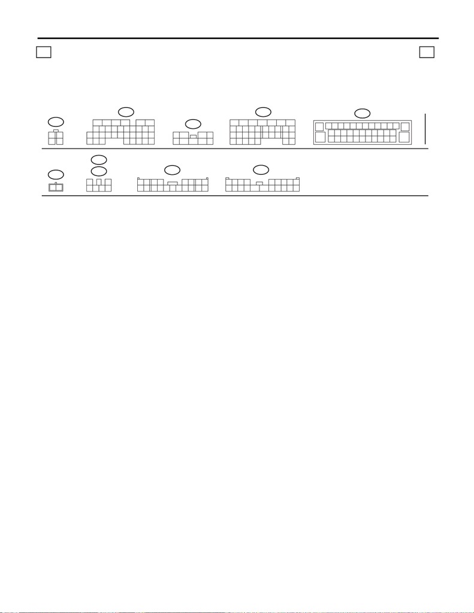

WI-400

Stop Light System

WIRING SYSTEM

(B)

B65

34

WI-44590

2b 2b

B159F:

1

5

76

2

8

34

9

B280

18

2719 20 21 22

23

26

24

25

98

15

1413121110

17

16

1234567

A:

B310

23456789

1

10 11 12 13

14

15

26

16 17 18 19 20 21 22 23 24 25

27 28 29 30 31 32 33 34 35 36 37

38

5

6

34

21

R28

R26

R168B:

1234

56789

10 11 12 13 14 15 16 17 18 19 20

(B)

R82

1

9

234 5678

10 11 12 14 15 16 17 18 1913

R19

12

B136C:

19

18

21

20

2322 24 25 26

17

1

23

4

56

27

28 29 30

31 32 33 34 35

798

151413121110 16

LIST OF CONNECTORS